# Ass_1

Simba

11/11/2020

Assignment 1

Create bar or line charts showing monthly total kBTUs of residential and commercial electricity and gas consumption for the Bay Area (meaning the sum of all ZIP codes in the 9 Bay Area counties) from 2017 to the latest available month (meaning a 42-column version of the plots from section 1.8). Look online for the correct conversion of kWhs to kBTUs and therms to kBTUs. Make sure that electricity and gas data are distinguishable but plotted in the same chart; feel free to separate your analyses for residential and commercial into two separate charts if you believe it improves legibility, or do one chart with 4 colors in the legend.

Comment on any observable changes in energy consumption that may be attributable to the COVID-19 pandemic. Create at least one map that highlights which neighborhoods experienced the greatest change in electricity consumption before and after the pandemic began, and comment on your results. Explain any key assumptions you made in the analysis, or caveats about the data sources that you think the reader should be aware of. Publish all of this work in a web report

```r
library(tidyverse)
library(plotly)
library(sf)
library(tigris)
library(leaflet)
library(censusapi)
library(dplyr)

Sys.setenv(CENSUS_KEY="c8aa67e4086b4b5ce3a8717f59faa9a28f611dab")
```

# read data for 2017-2019 elec

```r
library(tidyverse)

years <- 2017:2019
quarters <- 1:4
type <- "Electric"

pge_17_19_elec <- NULL

for (year in years){
for(quarter in quarters) {

  filename <-
    paste0(
      "PGE_",
      year,
      "_Q",
      quarter,
      "_",
      type,
      "UsageByZip.csv"
    )

  print(filename)

  temp <- read_csv(filename)

  pge_17_19_elec <- rbind(pge_17_19_elec,temp)
  # Note rbind requires field names to be consistent for every new thing that you add.

  saveRDS(pge_17_19_elec, "pge_17_19_elec.rds")
}}
```

```
## [1] "PGE_2017_Q1_ElectricUsageByZip.csv"
## [1] "PGE_2017_Q2_ElectricUsageByZip.csv"
## [1] "PGE_2017_Q3_ElectricUsageByZip.csv"
## [1] "PGE_2017_Q4_ElectricUsageByZip.csv"
## [1] "PGE_2018_Q1_ElectricUsageByZip.csv"
## [1] "PGE_2018_Q2_ElectricUsageByZip.csv"
## [1] "PGE_2018_Q3_ElectricUsageByZip.csv"
## [1] "PGE_2018_Q4_ElectricUsageByZip.csv"
## [1] "PGE_2019_Q1_ElectricUsageByZip.csv"
## [1] "PGE_2019_Q2_ElectricUsageByZip.csv"
## [1] "PGE_2019_Q3_ElectricUsageByZip.csv"
## [1] "PGE_2019_Q4_ElectricUsageByZip.csv"
```

# read data for 2020 Q1-3 AND combine with above-elec

```r
year <- 2020
quarters <- 1:3
type <- "Electric"

pge_20_elec <- NULL
for(quarter in quarters) {
   filename <-
    paste0(
      "PGE_",
      year,
      "_Q",
      quarter,
      "_",
      type,
      "UsageByZip.csv"
    )

  print(filename)

  temp <- read_csv(filename)

  pge_20_elec <- rbind(pge_20_elec,temp)

  saveRDS(pge_20_elec, "pge_20_elec.rds")
}
```

```
## [1] "PGE_2020_Q1_ElectricUsageByZip.csv"
## [1] "PGE_2020_Q2_ElectricUsageByZip.csv"
## [1] "PGE_2020_Q3_ElectricUsageByZip.csv"
```

```r
# combine all data for electricity
pge_elec<- rbind(pge_17_19_elec,pge_20_elec)
```

# read data for 2017-2019-gas

```r
library(tidyverse)

year <- 2017:2019
quarters <- 1:4
type <- "Gas"

pge_17_19_gas <- NULL

for (year in years){
for(quarter in quarters) {

  filename <-
    paste0(
      "PGE_",
      year,
      "_Q",
      quarter,
      "_",
      type,
      "UsageByZip.csv"
    )

  print(filename)

  temp <- read_csv(filename)

  pge_17_19_gas <- rbind(pge_17_19_gas,temp)
  # Note rbind requires field names to be consistent for every new thing that you add.

  saveRDS(pge_17_19_gas, "pge_17_19_gas.rds")}}
```

```
## [1] "PGE_2017_Q1_GasUsageByZip.csv"
## [1] "PGE_2017_Q2_GasUsageByZip.csv"
## [1] "PGE_2017_Q3_GasUsageByZip.csv"
## [1] "PGE_2017_Q4_GasUsageByZip.csv"
## [1] "PGE_2018_Q1_GasUsageByZip.csv"
## [1] "PGE_2018_Q2_GasUsageByZip.csv"
## [1] "PGE_2018_Q3_GasUsageByZip.csv"
## [1] "PGE_2018_Q4_GasUsageByZip.csv"
## [1] "PGE_2019_Q1_GasUsageByZip.csv"
## [1] "PGE_2019_Q2_GasUsageByZip.csv"
## [1] "PGE_2019_Q3_GasUsageByZip.csv"
## [1] "PGE_2019_Q4_GasUsageByZip.csv"
```

# read data for 20-gas and combine

```r
year <- 2020
quarters <- 1:3
type <- "Gas"

pge_20_gas <- NULL
for(quarter in quarters) {
   filename <-
    paste0(
      "PGE_",
      year,
      "_Q",
      quarter,
      "_",
      type,
      "UsageByZip.csv"
    )

  print(filename)

  temp <- read_csv(filename)

  pge_20_gas <- rbind(pge_20_gas,temp)

  saveRDS(pge_20_gas, "pge_20_gas.rds")
}
```

```
## [1] "PGE_2020_Q1_GasUsageByZip.csv"
## [1] "PGE_2020_Q2_GasUsageByZip.csv"
## [1] "PGE_2020_Q3_GasUsageByZip.csv"
```

```r
# combine all data for electricity
pge_gas<- rbind(pge_17_19_gas,pge_20_gas)
```

# get bay zipcodes

```r
bay_zipcodes<-read_csv("bayarea_zipcodes.csv")
```

#DATA cleaning and organization, pge_final_elec

```r
pge_final_elec <-
pge_elec %>%
  filter(ZIPCODE %in% bay_zipcodes$ZIP) %>%
  filter(CUSTOMERCLASS %in% c("Elec- Commercial", "Elec- Residential")) %>%
  select(!c(COMBINED, AVERAGEKWH)) %>%
  group_by(YEAR,MONTH, CUSTOMERCLASS) %>%
  summarise(
    TOTALKWH = sum(TOTALKWH,na.rm = T),
    TOTALCUSTOMERS =sum(TOTALCUSTOMERS,na.rm = T)
  ) %>%
  mutate(
    TOTALKBTU =
      TOTALKWH*3.412
  ) %>%
  select(!c(TOTALKWH, TOTALCUSTOMERS))

pge_final_elec
```

```
## # A tibble: 90 x 4
## # Groups:   YEAR, MONTH [45]
##     YEAR MONTH CUSTOMERCLASS       TOTALKBTU
##    <dbl> <dbl> <chr>                   <dbl>
##  1  2017     1 Elec- Commercial  5203095782.
##  2  2017     1 Elec- Residential 3396906305.
##  3  2017     2 Elec- Commercial  3310609649.
##  4  2017     2 Elec- Residential 2707102579.
##  5  2017     3 Elec- Commercial  3618184720.
##  6  2017     3 Elec- Residential 2623750943.
##  7  2017     4 Elec- Commercial  3531446924.
##  8  2017     4 Elec- Residential 2398807852.
##  9  2017     5 Elec- Commercial  3808860106.
## 10  2017     5 Elec- Residential 2494508546.
## # … with 80 more rows
```

#DATA cleaning and organization, pge_final_gas

```r
pge_final_gas <-
pge_gas %>%
  filter(ZIPCODE %in% bay_zipcodes$ZIP) %>%
  filter(CUSTOMERCLASS %in% c("Gas- Commercial", "Gas- Residential")) %>%
  select(!c(COMBINED, AVERAGETHM)) %>%
  group_by(YEAR,MONTH, CUSTOMERCLASS) %>%
  summarise(
    TOTALTHM = sum(TOTALTHM,na.rm = T),
    TOTALCUSTOMERS =sum(TOTALCUSTOMERS,na.rm = T)
  )%>%
  mutate(
    TOTALKBTU =
      TOTALTHM*99.976
  ) %>%
  select(!c(TOTALCUSTOMERS, TOTALTHM))

pge_final_gas
```

```
## # A tibble: 90 x 4
## # Groups:   YEAR, MONTH [45]
##     YEAR MONTH CUSTOMERCLASS       TOTALKBTU
##    <dbl> <dbl> <chr>                   <dbl>
##  1  2017     1 Gas- Commercial   3305396814.
##  2  2017     1 Gas- Residential 12928308961
##  3  2017     2 Gas- Commercial   2376719150.
##  4  2017     2 Gas- Residential  8596086344.
##  5  2017     3 Gas- Commercial   2227861385.
##  6  2017     3 Gas- Residential  6900568366.
##  7  2017     4 Gas- Commercial   1848136241.
##  8  2017     4 Gas- Residential  5490064168.
##  9  2017     5 Gas- Commercial   1682594780.
## 10  2017     5 Gas- Residential  4230467944.
## # … with 80 more rows
```

# seperate commercial and residential, convert time

```r
pge_final<-rbind(pge_final_elec,pge_final_gas)

pge_commerical<-
pge_final %>% filter(CUSTOMERCLASS %in% c("Elec- Commercial", "Gas- Commercial"))
pge_commerical$TIME <- with(pge_commerical, sprintf("%d-%02d", YEAR, MONTH))

pge_residential<-
pge_final %>% filter(CUSTOMERCLASS %in% c("Elec- Residential", "Gas- Residential"))
pge_residential$TIME <- with(pge_residential, sprintf("%d-%02d", YEAR, MONTH))
```

# chart-plotting-commercial

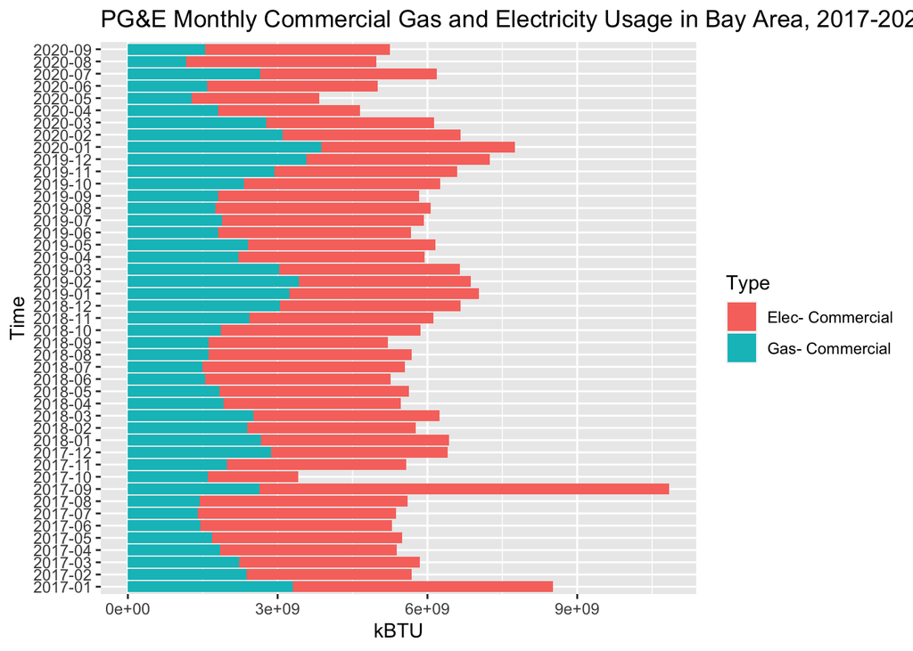

```r
pge_chart_commercial <-
  pge_commerical %>%
  ggplot() +
  geom_bar(
    aes(
      x = TIME,
      y = TOTALKBTU,
      fill = CUSTOMERCLASS
    ),
    stat = "identity",
    position = "stack"
  ) +
  labs(
    x = "Time",
    y = "kBTU",
    title = "PG&E Monthly Commercial Gas and Electricity Usage in Bay Area, 2017-2020",
    fill = "Type"
  )+coord_flip()

pge_chart_commercial
```

Despite the seasonal changes, it could be observed that the commercial energy use did experienced a decrease, while the gas consumption experienced even a greater change, which can be attributed to the closures of a wide range of businesses. It also should be noted that PG&E only cover a portion of the bay area so should not be used to reflect the situation of the entire bay area. For the purpose of this assignment, it is assumed that through the length of the record period, the households/area that PG&E supplies remain the same, as well as the way of recording the energy usage.

# chart-plotting-residential

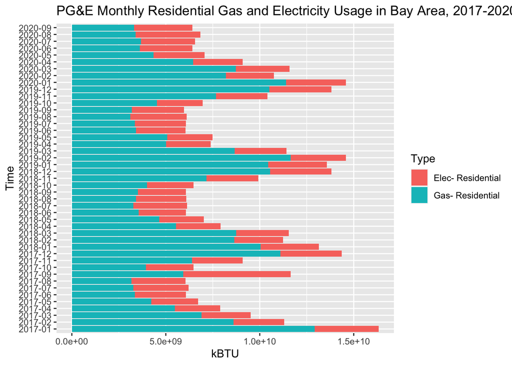

```r
pge_chart_residential <-
  pge_residential %>%
  ggplot() +
  geom_bar(
    aes(
      x = TIME,
      y = TOTALKBTU,
      fill = CUSTOMERCLASS
    ),
    stat = "identity",
    position = "stack"
  ) +
  labs(
    x = "Time",
    y = "kBTU",
    title = "PG&E Monthly Residential Gas and Electricity Usage in Bay Area, 2017-2020",
    fill = "Type"
  )+coord_flip()

pge_chart_residential
```

A slight increase can be observed after the start of covid-19. When compared to electricity, a greater change in gas consumption can be observed. #Find the neighborhoods with the greatest changes

```r
#calculate the avg for each zipcode in 17-19
  pge_17_19_tot <-
  pge_17_19_elec %>%
  filter(ZIPCODE %in% bay_zipcodes$ZIP) %>%
  select(!c(COMBINED, AVERAGEKWH,CUSTOMERCLASS)) %>%
  group_by(ZIPCODE)%>%
  summarise(
    TOTALKWH = sum(TOTALKWH,na.rm = T),
    TOTALCUSTOMERS =sum(TOTALCUSTOMERS,na.rm = T)
  ) %>%
mutate(
    AVGKWH_before =
      TOTALKWH/TOTALCUSTOMERS) %>%
  select(!c(TOTALKWH,TOTALCUSTOMERS))

#calculate the avg for each zipcode in 20
  pge_20_tot <-
  pge_20_elec %>%
  filter(ZIPCODE %in% bay_zipcodes$ZIP) %>%
  select(!c(COMBINED, AVERAGEKWH,CUSTOMERCLASS)) %>%
  group_by(ZIPCODE)%>%
  summarise(
    TOTALKWH = sum(TOTALKWH,na.rm = T),
    TOTALCUSTOMERS =sum(TOTALCUSTOMERS,na.rm = T)
  ) %>%
mutate(
    AVGKWH_after =
      TOTALKWH/TOTALCUSTOMERS) %>%
      select(!c(TOTALKWH,TOTALCUSTOMERS))

#merge two df
 total_bf_temp<-merge(pge_17_19_tot,pge_20_tot,by="ZIPCODE")
 total_bf<-
   total_bf_temp%>% mutate(DIFF=AVGKWH_after-AVGKWH_before)
 #total_order<-arrange(total_bf,DIFF)
```

#map_preparation

```r
ca_counties <- counties("CA", cb = T, progress_bar = F)
st_crs(ca_counties)
```

```
## Coordinate Reference System:
##   User input: NAD83
##   wkt:
## GEOGCRS["NAD83",
##     DATUM["North American Datum 1983",
##         ELLIPSOID["GRS 1980",6378137,298.257222101,
##             LENGTHUNIT["metre",1]]],
##     PRIMEM["Greenwich",0,
##         ANGLEUNIT["degree",0.0174532925199433]],
##     CS[ellipsoidal,2],
##         AXIS["latitude",north,
##             ORDER[1],
##             ANGLEUNIT["degree",0.0174532925199433]],
##         AXIS["longitude",east,
##             ORDER[2],
##             ANGLEUNIT["degree",0.0174532925199433]],
##     ID["EPSG",4269]]
```

```r
projection <- "+proj=utm +zone=10 +ellps=GRS80 +datum=NAD83 +units=ft +no_defs"

ca_counties_transformed <-
  ca_counties %>%
  st_transform(projection)

bay_county_names <-
  c(
    "Alameda",
    "Contra Costa",
    "Marin",
    "Napa",
    "San Francisco",
    "San Mateo",
    "Santa Clara",
    "Solano",
    "Sonoma"
  )

bay_counties <-
  counties("CA", cb = T, progress_bar = F) %>%
  filter(NAME %in% bay_county_names)

decrese_t<-c("94105","94104","95134")
increase_t<-c("94111","94533","94545")

usa_zips <-
  zctas(cb = T, progress_bar = F)

bay_zips <-
  usa_zips %>%
  st_centroid() %>%
  .[bay_counties, ] %>%
  st_set_geometry(NULL) %>%
  left_join(usa_zips %>% select(GEOID10)) %>%
  st_as_sf()
```

```r
total_map1 <-
  total_bf %>%
  mutate(
    ZIPCODE = ZIPCODE %>% as.character()
  ) %>%
  right_join(
    bay_zips %>% select(GEOID10),
    by = c("ZIPCODE" = "GEOID10")
  ) %>%
  st_as_sf() %>%
  st_transform(4326)

total_map<-filter(total_map1, DIFF!="NaN"& DIFF!= "NA")
```

```r
res_pal <- colorNumeric(
  palette = "Blues",
  domain = total_map$DIFF
)

leaflet() %>%
  addTiles() %>%
  addPolygons(
    data = total_map,
    fillColor = ~res_pal(DIFF),
    color = "white",
    opacity = 0.1,
    fillOpacity = 0.5,
    weight = 1,
    label = ~paste0(
      round(DIFF),
      " kWh difference in",
      ZIPCODE
    ),
    highlightOptions = highlightOptions(
      weight = 2,
      opacity = 1
    ))%>%
    addPolygons(
    data = total_map %>%
      filter(ZIPCODE %in% decrese_t) %>%
      st_transform(4326),
    color = "red") %>%
   addPolygons(
    data = total_map %>%
      filter(ZIPCODE %in% increase_t) %>%
      st_transform(4326),
    color = "green") %>%
  addLegend(
    data = total_map,
    pal = res_pal,
    values = ~DIFF,
    title = "Difference in Total Elec Usage Pre/Post- Covid-19")
```

[interactive chart not shown]

Due to the outliers in the difference in electricity use, the color coding was not very informative in this case. Therefore, the areas with the greatest increase and decrease are marked here in the map using green and red, respectively. It was then found that the changes in energy use varies considerably regrading the location, which can be potentially due to the different uses of land.